# Classifying [NSynth Instruments](https://magenta.tensorflow.org/datasets/nsynth) using Fully Connected And Convolutional Neural Nets

### And fighting overfitting while we do it...

```python
import numpy as np
import matplotlib.pyplot as plt
import IPython.display as ipd
import torch
from torch import nn
from torch.utils.data import Dataset, DataLoader
from scipy import signal
import librosa
```

# Convolutional Layers

Given an array of length $M$ referred to as the *kernel* k, we apply a "convolution" (cross-correlation) with an array $x$ with $N$ element as

### $y[i] = \sum_{j=0}^{M-1} k[j] x[i-M/2+j]$

### Rect

[figure not shown]

## Deriv

[figure not shown]

## Laplacian (Second Derivative)

[figure not shown]

## Matched Gabor Cosine

[figure not shown]

## Mismatched Gabor Cosine

[figure not shown]

# Torch Convolutional Layers

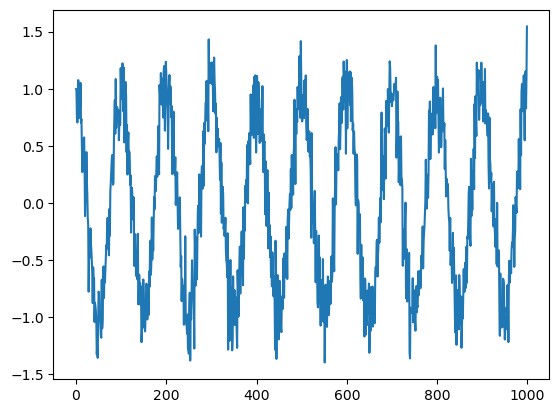

```python
def get_gauss_derivs(sigma):
    """
    Compute a Gaussian and is first 3 derivatives

    Parameters
    ----------
    sigma: int
        The width of the Gaussian, in samples

    Returns
    -------
    g, g1, g2, g3: ndarray(6*sigma+1)
        The gaussian and its first 3 derivatives, sampled up to 3 sigma on each side
    """
    t = np.arange(-2*sigma, 2*sigma)
    g = np.exp(-t**2/(2*sigma))/(np.sqrt(2*np.pi)*sigma)

    # First derivative, normalized so the derivative of f(t) = t is 1
    g1 = (-t/sigma)*g
    g1 /= np.sum(-g1*t)

    # Second derivative, normalize so the second derivative of f(t) = t^2 is 2
    g2 = (t**2/sigma**2 - 1/sigma)*g
    g2 = g2*2/np.sum(g2*t**2)
    return g, g1, g2

N = 1000
t = np.linspace(0, 20*np.pi, N)
x = np.cos(t) + np.random.randn(N)*0.2
sigma = 50
kernel1, kernel2, kernel3 = get_gauss_derivs(sigma)
x = torch.from_numpy(np.array(x, dtype=np.float32))
plt.plot(x)
```

```python
layer = nn.Conv1d(in_channels=1, out_channels=3, kernel_size=len(kernel1))
s = layer.state_dict()
s['weight'][0, 0, :] = torch.from_numpy(np.array(kernel1, dtype=np.float32))
s['weight'][1, 0, :] = torch.from_numpy(np.array(kernel2, dtype=np.float32))
s['weight'][2, 0, :] = torch.from_numpy(np.array(kernel2, dtype=np.float32))

# Reshape x so that it's 1x1x1000 (3D Array)
# Example Number x Channel Index x Number of samples
x = x.view(1, 1, len(x))
y = layer(x)
```

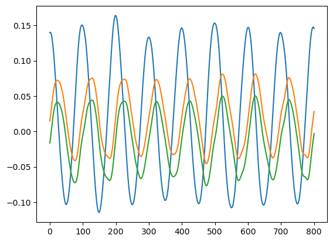

```python
plt.plot(y[0, :, :].detach().T)
```

# Torch Data Loader for NSynth Data

2 strategies to fight overfitting:

1. Increase the complexity of your training data
- Get more data
- Data augmentation: take the existing data, and instead of returning it directly in the dataset, do some transformation to it that makes sense (TL;DR; Taking the data we have and make new fake examples based on it)
1. "Regularize" or simplify the model
- Use fewer parameters
- Use same # of parameters but add a "regularization" term (e.g. a penalty for the sum of squares of all weights)
- Dropout, where you randomly zero out outputs after a particular layer
- Early stopping; when the train set accuracy starts to pull away from the test set accuracy, stop training

Below is an example of doing data augmentation by warping the data slightly in time

```python
x = data_test[100][0].flatten()
ipd.Audio(x, rate=sr) # Original data
```

[interactive chart not shown]

[interactive chart not shown]

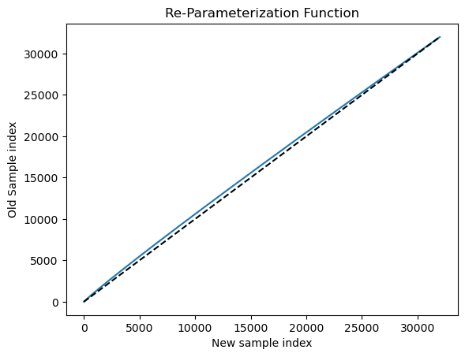

```python
# Warp the audio slightly in time.
# If p < 1, it starts off faster and slows down
# if p > 1, it starts off slower and speeds up
p = 0.95
idx = (np.linspace(0, 1, len(x))**p)*(len(x)-1)
plt.plot(idx)
plt.plot(np.arange(len(x)), np.arange(len(x)), c='k', linestyle='--')
plt.xlabel("New sample index")
plt.ylabel("Old Sample index")
plt.title("Re-Parameterization Function")
xwarp = np.interp(idx, np.arange(len(x)), x)
ipd.Audio(xwarp, rate=sr)
```

```python
LABELS = ['bass_electronic', 'bass_synthetic', 'brass_acoustic',
          'flute_acoustic', 'flute_synthetic', 'guitar_acoustic',
          'guitar_electronic', 'keyboard_acoustic',
          'keyboard_electronic', 'keyboard_synthetic',
          'mallet_acoustic', 'organ_electronic', 'reed_acoustic',
          'string_acoustic', 'vocal_acoustic', 'vocal_synthetic']

class Synth(Dataset):
    def __init__(self, audio_filename, labels_filename, sr=8000, sample_len=4, augment=False):
        """
        Parameters
        ----------
        audio_filename: string
            Path to audio file
        labels_filename: string
            Path to labels file
        sr: int
            Audio sample rate to use
        sample_len: int
            Length of each sample, in seconds
        augment: bool
            If true, do data augmentation when accesing an item
        """
        self.x, self.sr = librosa.load(audio_filename, sr=sr)
        self.labels = np.loadtxt(labels_filename)
        print("Finished loading audio ", audio_filename)
        self.sample_len = sample_len
        self.augment = augment

    def __len__(self):
        return len(self.labels)

    def __getitem__(self, idx):
        """
        Return a tuple (x, y)
        """
        L = self.sr*sample_len
        x = self.x[L*idx:L*idx+L]
        if self.augment:
            #p = np.random.rand()*0.02 + 0.99 # Random # between 0.99 and 1.01
            #i = (np.linspace(0, 1, len(x))**p)*(len(x)-1)
            #x = np.interp(i, np.arange(len(x)), x)
            x = x + 0.01*np.random.randn(len(x))
        x = np.reshape(x, (1, len(x)))
        label = int(self.labels[idx])
        y = np.zeros(len(LABELS))
        y[label] = 1
        x = torch.from_numpy(np.array(x, dtype=np.float32))
        y = torch.from_numpy(np.array(y, dtype=np.float32))
        return x, y
```

```python
sr = 8000
sample_len = 4
data_train = Synth("data/nsynth_valid.mp3", "data/labels_valid.txt", sr, sample_len, True)
data_test = Synth("data/nsynth_test.mp3", "data/labels_test.txt", sr, sample_len)
```

```
Finished loading audio  data/nsynth_valid.mp3
Finished loading audio  data/nsynth_test.mp3
```

## PyTorch Training Loop

The code below trains the neural network on one dataset and tests it on another, completely disjoint dataset. It is crucial that we test it on a different dataset from which we trained it to make sure it's not just "memorizing" the data in the training set. Such an undesirable scenario is referred to as *overfitting*

First we'll play a little bit with the convolution layer and its shape to make sure we have everything right

```python
win = 512
hop = 512
# A drop in replacement for flattened MFCC
conv1 = nn.Conv1d(in_channels=1, out_channels=40, kernel_size=win,
                  stride=hop, bias=False)

flatten = nn.Flatten()

loader = DataLoader(data_train, batch_size=64, shuffle=True)
X, Y = next(iter(loader))
out = conv1(X)

print("X.shape", X.shape)
print("out.shape", out.shape)

flat = flatten(out)
dim = flat.shape[1]
print("flat.shape", flat.shape)
```

[output not shown]

Now let's do the training

```python
# Try to use the GPU
device = torch.device('cuda' if torch.cuda.is_available() else 'cpu')
print("Device: ", device)

model = nn.Sequential(
    conv1,
    nn.ReLU(),
    flatten,
    nn.Linear(dim, 100),
    nn.ReLU(),
    nn.Linear(100, 200),
    nn.ReLU(),
    nn.Linear(200, len(LABELS))
)


model = model.to(device)
params = sum([np.prod(p.size()) for p in model.parameters()])
print("Total Parameters:", params)

## Step 3: Setup the loss function
loss_fn = torch.nn.BCEWithLogitsLoss()
optimizer = torch.optim.Adam(model.parameters(), lr=0.0001)

n_epochs = 300 # Each "epoch" is a loop through the entire dataset
# and we use this to update the parameters

train_losses = []
train_accuracy = []
test_losses = []
test_accuracy = []
labels = []
outputs = []
for epoch in range(n_epochs):
    loader = DataLoader(data_train, batch_size=64, shuffle=True)
    train_loss = 0
    train_correct = 0
    for X, Y in loader: # Go through each mini batch
        # Move inputs/outputs to GPU
        X = X.to(device)
        Y = Y.to(device)
        # Reset the optimizer's gradients
        optimizer.zero_grad()
        # Run the sequential model on all inputs
        Y_est = model(X)
        # Compute the loss function comparing Y_est to Y
        loss = loss_fn(Y_est, Y)
        # Compute the gradients of the loss function with respect
        # to all of the parameters of the model
        loss.backward()
        # Update the parameters based on the gradient and
        # the optimization scheme
        optimizer.step()
        train_loss += loss.item()
        train_correct += torch.sum(torch.argmax(Y, axis=1) == torch.argmax(Y_est, axis=1))
    train_losses.append(train_loss/len(data_train))
    t = train_correct / len(data_train)
    train_accuracy.append(t.detach().cpu())

    # Look at results on test set
    test_loader = DataLoader(data_test, batch_size=256)
    test_loss = 0
    labels = []
    outputs = []
    for X, Y in test_loader:
        X = X.to(device)
        Y = Y.to(device)
        Y_est = model(X)
        loss = loss_fn(Y_est, Y)
        test_loss += loss.item()
        labels = labels + torch.argmax(Y, axis=1).detach().cpu().numpy().tolist()
        outputs = outputs + torch.argmax(Y_est, axis=1).detach().cpu().numpy().tolist()

    test_losses.append(test_loss/len(data_test))
    t = np.sum(np.array(labels) == np.array(outputs))
    test_accuracy.append(t/len(data_test))
    if epoch%10 == 0:
        print("Epoch {}, train accuracy {:.3f}, test accuracy {:.3f}".format(epoch, train_accuracy[-1], test_accuracy[-1]))
```

[output not shown]

## Plot Optimization Progress

We get very respectable performance on the test set (about 95%) approaching what we got before when we manually specified the MFCC. It's also an improvement over the ~87% we got before we did data augmentation

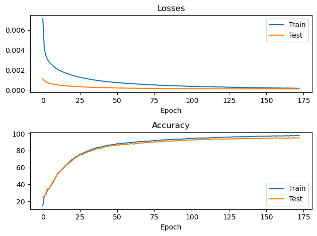

```python
plt.figure()
plt.subplot(211)
plt.plot(train_losses)
plt.plot(test_losses)
plt.title("Losses")
plt.xlabel("Epoch")
plt.legend(["Train", "Test"])
plt.subplot(212)
plt.plot(np.array(train_accuracy)*100)
plt.plot(np.array(test_accuracy)*100)
plt.title("Accuracy")
plt.xlabel("Epoch")
plt.legend(["Train", "Test"])
plt.tight_layout()
plt.savefig("Overfitting.svg")
```

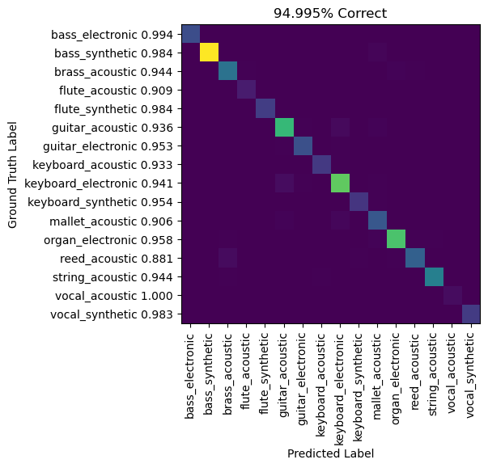

```python
def plot_confusion_matrix(labels, outputs):
    from scipy import sparse
    I = np.array(labels, dtype=int)
    J = np.array(outputs, dtype=int)
    K = len(LABELS)
    D = sparse.coo_matrix((np.ones(I.size), (I, J)), shape=(K, K))
    D = D.toarray()
    plt.imshow(D)
    plt.xticks(np.arange(K), LABELS, rotation='vertical')
    acc = np.diag(D)/np.sum(D, axis=1)
    plt.yticks(np.arange(K), ["{} {:.3f}".format(LABELS[i], acc[i]) for i in range(len(LABELS))])
    plt.ylabel("Ground Truth Label")
    plt.xlabel("Predicted Label")
    correct = 100*np.sum(np.diag(D))/np.sum(D)
    plt.title("{:.3f}% Correct".format(correct))

plot_confusion_matrix(labels, outputs)
```

When we look at the kernels we learned, we see we learn some mfcc-esque filterbank terms picking out different bands in frequency

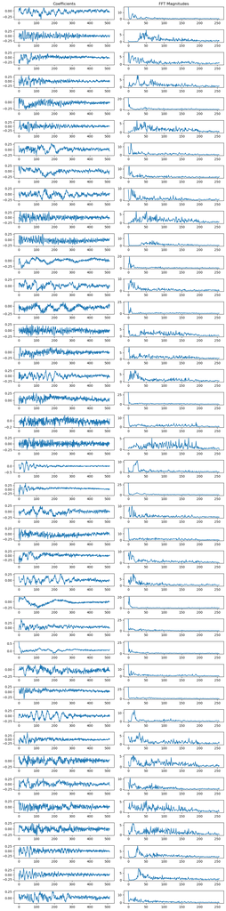

```python
filters = next(iter(model.parameters())).detach().cpu()

plt.figure(figsize=(10, 40))
for i in range(40):
    plt.subplot(40, 2, 2*i+1)
    plt.plot(filters[i, 0, :])
    if i == 0:
        plt.title("Coefficients")
    plt.subplot(40, 2, 2*i+2)
    if i == 0:
        plt.title("FFT Magnitudes")
    plt.plot(np.abs(np.fft.fft(filters[i, 0, :]))[0:win//2])

plt.tight_layout()
```